# Procesamiento de datos masivos con R y RStudio

Yolanda García Ruiz - ygarciar@ucm.es

23/09/2025

# 1 Ejercicios

## 1.1 Desarrollo en aula

Vamos a trabajar con un dataset que contiene las multas de circulación que el Ayuntamiento de Madrid ha tramitado durante el mes de Enero de 2024. Se encuentra en el fichero `202401detalle.csv`. Mas información en https://datos.madrid.es/portal/site/egob.

```r
library(readr)       # para lectura de datos
library(dplyr)       # procesamiento de tibbles
library(lubridate)   # gestión de fechas
library(stringr)     # para la gestión de cadenas
```

1. Crea un tibble a partir de los datos del fichero para cargar en R las multas del mes de Enero de 2024. Puedes usar la opción `Import Dataset` de la pestaña `Environment.`

   ```
   ## # A tibble: 5 × 14
   ##   CALIFICACION LUGAR        MES  ANIO HORA  IMP_BOL DESCUENTO PUNTOS DENUNCIANTE
   ##   <chr>        <chr>      <dbl> <dbl> <tim>   <dbl> <chr>      <dbl> <chr>
   ## 1 LEVE         MARIA DE …     1  2024 10:55      60 SI             0 AGENTES DE…
   ## 2 GRAVE        CORAZON D…     1  2024 11:05     200 SI             0 AGENTES DE…
   ## 3 LEVE         PADRE DAM…     1  2024 12:34      90 SI             0 AGENTES DE…
   ## 4 GRAVE        ABAD JUAN…     1  2024 11:40     200 SI             3 AGENTES DE…
   ## 5 LEVE         PZ CANALE…     1  2024 16:04      90 SI             0 AGENTES DE…
   ## # ℹ 5 more variables: `HECHO-BOL` <chr>, VEL_LIMITE <dbl>, VEL_CIRCULA <dbl>,
   ## #   `COORDENADA-X` <dbl>, `COORDENADA-Y` <dbl>
   ```

2. Muestra los 10 últimos registros cargados (`slice_tail()`).
3. Muestra las 10 primeras multas del dataframe (`slice_head()`).
4. Elimina las columnas mes y año (todos los datos son de enero de 2024, por lo que esas columnas no aportan nada).
5. Usa la operación `is.na()` para calcular el número de valores NA en las columnas del dataframe.
6. Encuentra la mayor diferencia en % de velocidad entre la velocidad permitida y a la que se circulaba: `(vel_circula-vel_limite)/vel_limite`.

   ```
   ## # A tibble: 1 × 4
   ##   CALIFICACION VEL_CIRCULA VEL_LIMITE diferencia
   ##   <chr>              <dbl>      <dbl>      <dbl>
   ## 1 GRAVE                 77         30       1.57
   ```

7. Muestra los datos de la multa en la que se circulaba a mayor velocidad (mayor diferencia de velocidad en % con respecto a la velocidad límite).
8. ¿Cuantos valores distintos existen en la columna CALIFICACION?

   ```
   ## [1] "LEVE"      "GRAVE"     "MUY GRAVE"
   ```

   ```
   ##
   ##     GRAVE      LEVE MUY GRAVE
   ##    128932    104160       789
   ```

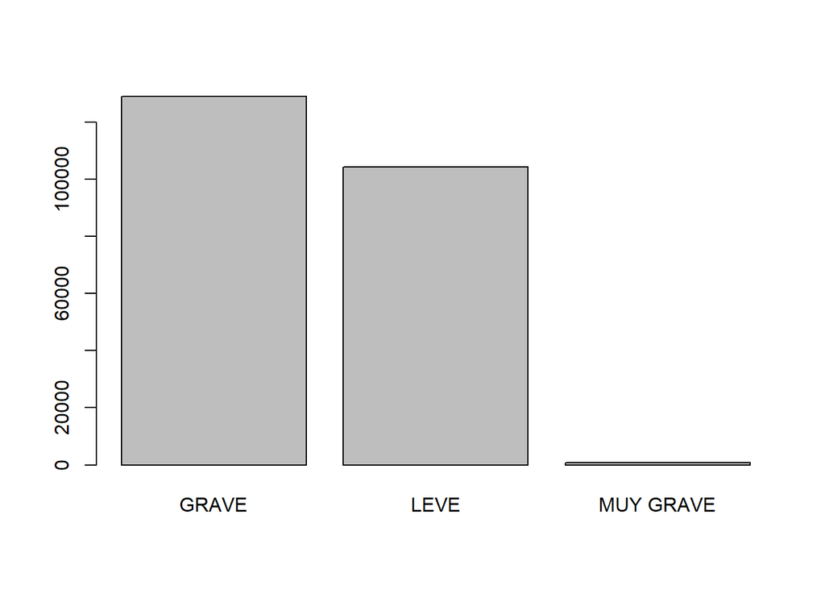

9. La columna denunciante tiene información acerca de la entidad que ha realizado la denuncia. Calcula la frecuencia de cada uno de los tipos de denunciante (función `table()`).

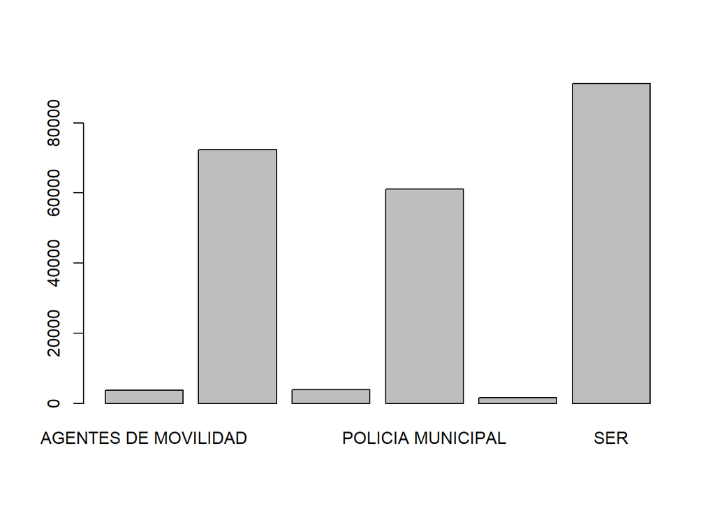

10. De todas las multas tramitadas, ¿cuántas han sido tramitadas por agentes de movilidad? Crea un nuevo dataframe que contenga solo las multas tramitadas por agentes de movilidad.
11. ¿Qué % de multas han tenido descuento por pronto pago?
12. ¿Cuánto dinero se ha recaudado en el mes de enero de 2024 con el cobro de las multas?

    ```
    ## [1] 30457320
    ```

13. ¿Cuánto dinero se ha recaudado en el mes de enero de 2024 con el cobro de las multas por tipo de tramitador?,¿ Cuántas multas se han tramitado por tipo de tramitador?. El importe de las pronto pago lleva un descuento del 50%

    ```
    ## # A tibble: 6 × 4
    ##   DENUNCIANTE                   importe_min importe_max num_multas
    ##   <chr>                               <dbl>       <dbl>      <int>
    ## 1 AGENTES DE MOVILIDAD               217925      435850       3715
    ## 2 MEDIOS DE CAPTACION DE IMAGEN     7203700    14407400      72290
    ## 3 MOVILIDAD RADAR                    202150      404300       3861
    ## 4 POLICIA MUNICIPAL                 3854905     7709810      61170
    ## 5 SACE                               144130      288260       1680
    ## 6 SER                               3605850     7211700      91165
    ```

14. ¿Cuánto dinero se ha recaudado en el mes de enero de 2024 con el cobro de las multas por tipo de tramitador y calificación?,¿ Cuántas multas se han tramitado por tipo de tramitador y calificación?. El importe de las pronto pago lleva un descuento del 50%.

    ```
    ## # A tibble: 13 × 4
    ##    DENUNCIANTE                   CALIFICACION importe_total num_multas
    ##    <chr>                         <chr>                <dbl>      <int>
    ##  1 AGENTES DE MOVILIDAD          GRAVE               105000       1050
    ##  2 AGENTES DE MOVILIDAD          LEVE                110175       2654
    ##  3 AGENTES DE MOVILIDAD          MUY GRAVE             2750         11
    ##  4 MEDIOS DE CAPTACION DE IMAGEN GRAVE              7183000      71830
    ##  5 MEDIOS DE CAPTACION DE IMAGEN LEVE                 20700        460
    ##  6 MOVILIDAD RADAR               GRAVE               202150       3861
    ##  7 POLICIA MUNICIPAL             GRAVE              3003750      47744
    ##  8 POLICIA MUNICIPAL             LEVE                555405      12648
    ##  9 POLICIA MUNICIPAL             MUY GRAVE           295750        778
    ## 10 SACE                          GRAVE               124600       1246
    ## 11 SACE                          LEVE                 19530        434
    ## 12 SER                           GRAVE               320100       3201
    ## 13 SER                           LEVE               3285750      87964
    ```

15. Número de multas por hora. Usa la función `hour()` para obtener la hora a partir de hh:mm.

    ```
    ## # A tibble: 24 × 3
    ##       hh importe_total num_multas
    ##    <int>         <dbl>      <int>
    ##  1     0        286205       3391
    ##  2     1        213505       2398
    ##  3     2        144975       1574
    ##  4     3        101270       1069
    ##  5     4         97115       1062
    ##  6     5        117590       1339
    ##  7     6        215485       2561
    ##  8     7        235430       2769
    ##  9     8        416765       5156
    ## 10     9       1118145      18646
    ## # ℹ 14 more rows
    ```

16. Dibuja diagrama de barras para representar el número de multas por hora. Usa la función `barplot()`.

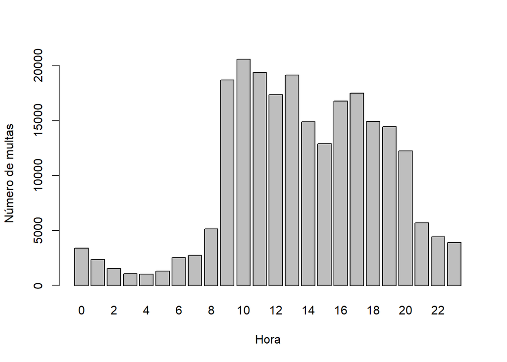

## 1.2 Para seguir practicando …

1. ¿Cuál ha sido la multa de mayor importe?
2. Cuál es la media del importe de las multas por tipo de calificación.
3. Multas por conducir usando un teléfono. Buscaremos la palabra TELEFON en la variable HECHO_BOL.

   ```r
   uso_telefono <- multas %>%
                   filter(str_detect(`HECHO-BOL`, 'TELEFON')) %>%
                   select(`HECHO-BOL`)
   uso_telefono
   ```

   ```
   ## # A tibble: 375 × 1
   ##    `HECHO-BOL`
   ##    <chr>
   ##  1 "CONDUCIR UTILIZANDO DISPOSITIVO DE TELEFON\xcdA M\xd3VIL, SUJET\xc1NDOLO CO…
   ##  2 "CONDUCIR UTILIZANDO DISPOSITIVO DE TELEFON\xcdA M\xd3VIL, SUJET\xc1NDOLO CO…
   ##  3 "CONDUCIR UTILIZANDO MANUALMENTE NAVEGADOR, SISTEMA DE COMUNICACI\xd3N O DIS…
   ##  4 "CONDUCIR UTILIZANDO DISPOSITIVO DE TELEFON\xcdA M\xd3VIL, SUJET\xc1NDOLO CO…
   ##  5 "CONDUCIR UTILIZANDO MANUALMENTE NAVEGADOR, SISTEMA DE COMUNICACI\xd3N O DIS…
   ##  6 "CONDUCIR UTILIZANDO DISPOSITIVO DE TELEFON\xcdA M\xd3VIL, SUJET\xc1NDOLO CO…
   ##  7 "CONDUCIR UTILIZANDO DISPOSITIVO DE TELEFON\xcdA M\xd3VIL, SUJET\xc1NDOLO CO…
   ##  8 "CONDUCIR UTILIZANDO DISPOSITIVO DE TELEFON\xcdA M\xd3VIL, SUJET\xc1NDOLO CO…
   ##  9 "CONDUCIR UTILIZANDO DISPOSITIVO DE TELEFON\xcdA M\xd3VIL, SUJET\xc1NDOLO CO…
   ## 10 "CONDUCIR UTILIZANDO MANUALMENTE NAVEGADOR, SISTEMA DE COMUNICACI\xd3N O DIS…
   ## # ℹ 365 more rows
   ```

   ```r
   # PISTA
   str_detect('USO DEL TELEFONO MÓVIL', 'TELEFON')
   ```

   ```
   ## [1] TRUE
   ```

   ```r
   str_detect('USO DEL MÓVIL', 'TELEFON')
   ```

   ```
   ## [1] FALSE
   ```

4. Dibuja un histograma del importe de las multas para analizar su distribución.

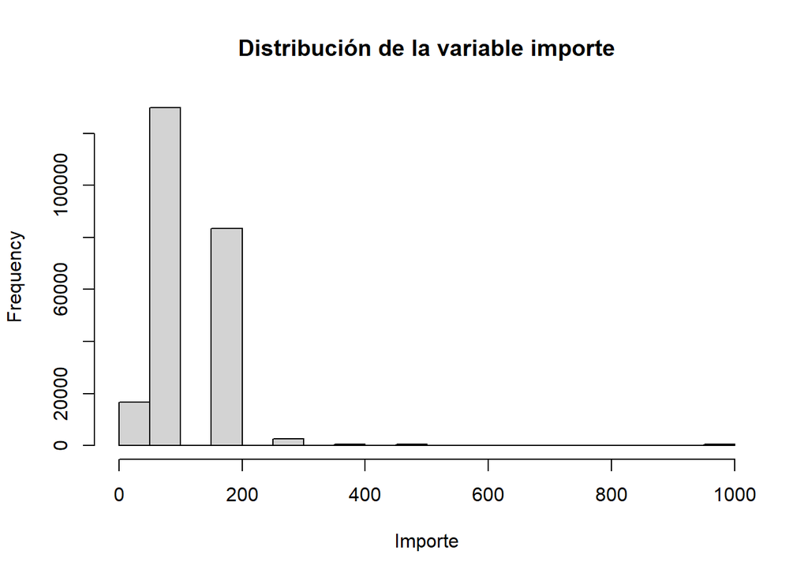

5. ¿Hay valores atípicos? Dibujar un diagrama de barras y bigotes para cada una de las calificaciones `boxplot` .

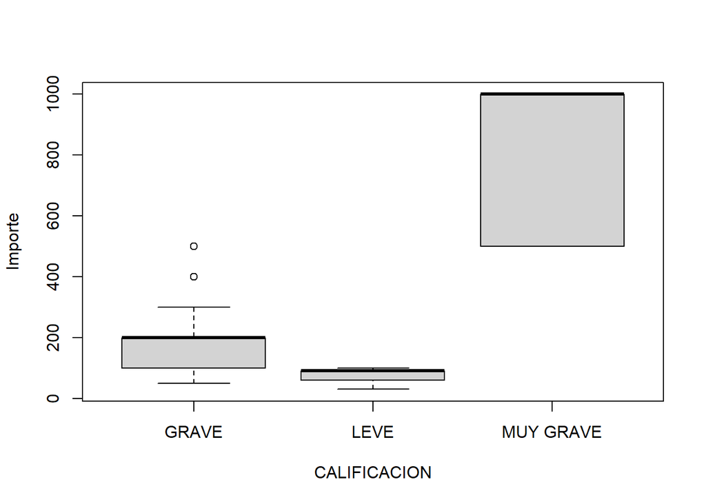

La función `boxplot()` detecta outliers como todo valor que está más allá de los bigotes. Los bigotes son las líneas que se determinan como el tercer cuartil + 1.5 veces el rango intercuartílico (Tercer cuartil menos el primer cuartil) y el primer cuartil -1.5 veces el rango intercuartílico (https://es.wikipedia.org/wiki/Valor_at%C3%ADpico).

```r
graves <- filter(multas, CALIFICACION == 'GRAVE')
# CALCULAMOS EL TANGO INTERCUARTÍLICO
rango <-IQR(graves$IMP_BOL, na.rm = T)

qs = quantile(graves$IMP_BOL, probs = c(0.25, 0.75))
lim_inf = qs[1] - 1.5 * rango
lim_sup = qs[2] + 1.5 * rango
lim_inf
```

```
## 25%
## -50
```

```r
lim_sup
```

```
## 75%
## 350
```

```r
sin_out <- multas %>%
           filter((CALIFICACION != 'GRAVE') |
                  (CALIFICACION == 'GRAVE') & (IMP_BOL > lim_inf & IMP_BOL < lim_sup))
sin_out
```

```
## # A tibble: 233,294 × 14
##    CALIFICACION LUGAR       MES  ANIO HORA  IMP_BOL DESCUENTO PUNTOS DENUNCIANTE
##    <chr>        <chr>     <dbl> <dbl> <tim>   <dbl> <chr>      <dbl> <chr>
##  1 LEVE         MARIA DE…     1  2024 10:55      60 SI             0 AGENTES DE…
##  2 GRAVE        CORAZON …     1  2024 11:05     200 SI             0 AGENTES DE…
##  3 LEVE         PADRE DA…     1  2024 12:34      90 SI             0 AGENTES DE…
##  4 GRAVE        ABAD JUA…     1  2024 11:40     200 SI             3 AGENTES DE…
##  5 LEVE         PZ CANAL…     1  2024 16:04      90 SI             0 AGENTES DE…
##  6 LEVE         PZ CANAL…     1  2024 16:07      90 SI             0 AGENTES DE…
##  7 GRAVE        PEDRO RI…     1  2024 09:11     200 SI             0 AGENTES DE…
##  8 GRAVE        PEDRO RI…     1  2024 09:14     200 SI             0 AGENTES DE…
##  9 GRAVE        REPUBLIC…     1  2024 09:09     200 SI             6 AGENTES DE…
## 10 LEVE         REPUBLIC…     1  2024 09:10      60 SI             0 AGENTES DE…
## # ℹ 233,284 more rows
## # ℹ 5 more variables: `HECHO-BOL` <chr>, VEL_LIMITE <dbl>, VEL_CIRCULA <dbl>,
## #   `COORDENADA-X` <dbl>, `COORDENADA-Y` <dbl>
```

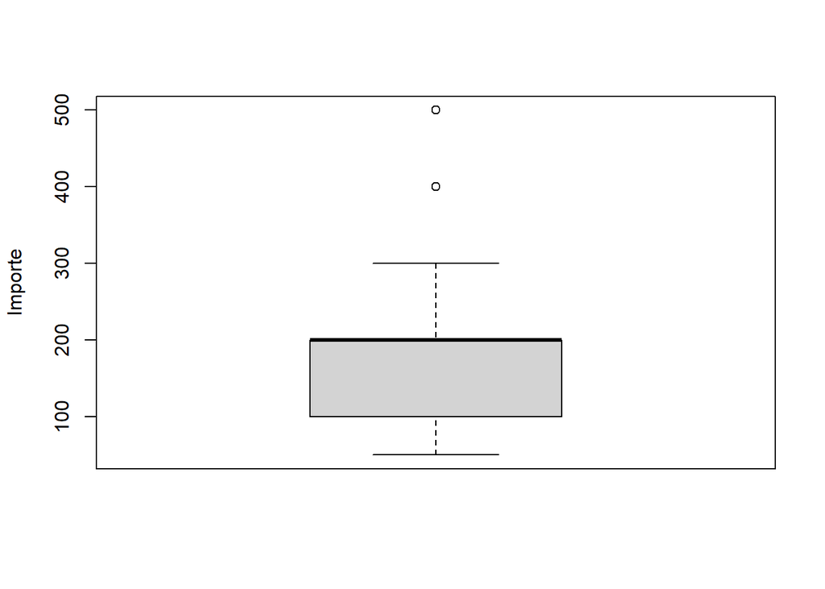

```r
graves <- filter(multas, CALIFICACION == 'GRAVE')
b <- boxplot(graves$IMP_BOL,   ylab = "Importe")
```

```r
b$out
```

```
##   [1] 400 400 500 500 400 400 500 500 500 500 400 400 400 400 400 500 400 400
##  [19] 400 500 400 400 500 400 400 400 500 400 400 400 400 400 400 400 400 400
##  [37] 400 500 400 400 400 400 400 400 400 500 400 500 500 500 400 500 400 400
##  [55] 400 400 500 500 500 500 400 400 400 400 400 500 400 400 400 400 500 400
##  [73] 400 500 400 500 500 400 400 400 500 500 400 400 400 500 400 400 400 400
##  [91] 400 400 400 400 400 400 500 400 400 400 500 400 400 500 500 400 500 400
## [109] 400 500 400 500 400 400 500 400 400 400 500 400 400 400 400 400 400 400
## [127] 400 400 500 500 400 400 500 400 400 400 400 400 400 400 400 500 500 400
## [145] 400 400 500 500 400 400 400 400 400 400 400 500 500 400 400 400 400 400
## [163] 400 400 500 400 400 500 400 400 400 500 500 500 400 400 400 400 400 400
## [181] 400 500 400 400 400 500 400 400 400 400 500 400 400 400 400 400 400 400
## [199] 500 400 400 400 400 400 400 400 400 400 400 400 400 400 400 400 400 400
## [217] 400 500 500 400 500 400 400 400 400 400 400 400 400 400 500 400 400 500
## [235] 400 500 400 400 400 400 400 400 400 400 400 400 500 400 400 400 400 400
## [253] 400 400 400 400 400 400 400 400 400 400 400 400 400 400 400 500 500 400
```

[output cut: 18 more lines]

Para eliminar los outliers:

```r
multas %>% filter((CALIFICACION == 'GRAVE'& !(IMP_BOL %in% b$out)) |    (CALIFICACION != 'GRAVE'))
```

```
## # A tibble: 233,294 × 14
##    CALIFICACION LUGAR       MES  ANIO HORA  IMP_BOL DESCUENTO PUNTOS DENUNCIANTE
##    <chr>        <chr>     <dbl> <dbl> <tim>   <dbl> <chr>      <dbl> <chr>
##  1 LEVE         MARIA DE…     1  2024 10:55      60 SI             0 AGENTES DE…
##  2 GRAVE        CORAZON …     1  2024 11:05     200 SI             0 AGENTES DE…
##  3 LEVE         PADRE DA…     1  2024 12:34      90 SI             0 AGENTES DE…
##  4 GRAVE        ABAD JUA…     1  2024 11:40     200 SI             3 AGENTES DE…
##  5 LEVE         PZ CANAL…     1  2024 16:04      90 SI             0 AGENTES DE…
##  6 LEVE         PZ CANAL…     1  2024 16:07      90 SI             0 AGENTES DE…
##  7 GRAVE        PEDRO RI…     1  2024 09:11     200 SI             0 AGENTES DE…
##  8 GRAVE        PEDRO RI…     1  2024 09:14     200 SI             0 AGENTES DE…
##  9 GRAVE        REPUBLIC…     1  2024 09:09     200 SI             6 AGENTES DE…
## 10 LEVE         REPUBLIC…     1  2024 09:10      60 SI             0 AGENTES DE…
## # ℹ 233,284 more rows
## # ℹ 5 more variables: `HECHO-BOL` <chr>, VEL_LIMITE <dbl>, VEL_CIRCULA <dbl>,
## #   `COORDENADA-X` <dbl>, `COORDENADA-Y` <dbl>
```